# Práctica 14. Comparación de medias (II)

Mi nombre

2024-12-16

En primer lugar, vamos a preparar una base de datos de nuestro directorio de trabajo, df_iam4_r, que puedes obtener de la Carpeta de la Práctica 14 en el Aula Virtual:

```r
df_iam4<-read.csv ("df_iam4_r.csv")
```

Recurda sus características. Se incluyeron características sociodemográficas de 984 sujetos ( `fech_nac`, `sex` y `clas_soc` ), clínicas (`hta` , `DM`, `colesterol` , `salud`) y el hábito tabáquico (`fum`). En un momento en el tiempo se recogió qué sujetos habían tenido un evento tipo infarto de miocardio `iam`). Posteriormenete se siguió a los sujetos hasta otro punto en el tiempo. Tras ese punto t, sólo se recogió si el sujeto seguía fumando tras el primer infarto (`fum_p`) , la cifra de colesterol (`colesterol_p`), la percepción de salud posterior al infarto (`salud_p` ) y la ocurrencia de un nuevo reinfarto (`iam2`). Asumimos (lo que puede tener poca plausibilidad) que quien no tuvo `iam1` en el tiempo t, no tuvo nuevo infarto.

## 1. ANOVA de una vía

Se pretende comparar las cifras de colesterol por clase social. Para ello usaremos un ANOVA de una vía.

Primero evaluaremos visualmente las diferencias

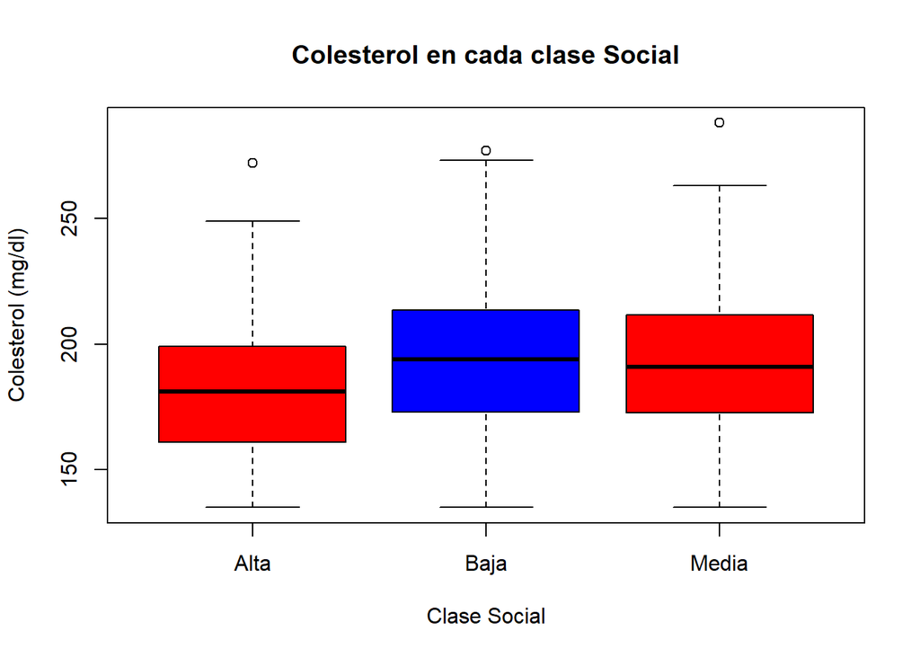

```r
boxplot(colesterol ~ clas_soc, data = df_iam4,
        main = "Colesterol en cada clase Social",
        xlab = "Clase Social",
        ylab = "Colesterol (mg/dl)",
        col = c("red", "blue"),  # Colores para las cajas
        border = "black")  # Color del borde
```

Parece que la clase “Alta” tiene valores más bajos de colesterol, vamos a estudiarlo formalmente con una ANOVA. Se puede hacer directamente con el paquete base `Stats` o con la librería `cars`

```r
# Debemos asegurarnos de que la variable clas_soc es un factor()
df_iam4$clas_soc<- as.factor(df_iam4$clas_soc)

test_anova<-aov(colesterol~clas_soc,data=df_iam4)
anova(test_anova)
```

```
## Analysis of Variance Table
##
## Response: colesterol
##            Df Sum Sq Mean Sq F value    Pr(>F)
## clas_soc    2  18277  9138.6  11.397 1.279e-05 ***
## Residuals 981 786612   801.8
## ---
## Signif. codes:  0 '***' 0.001 '**' 0.01 '*' 0.05 '.' 0.1 ' ' 1
```

Con el paquete `cars`

```r
library(car)
# Crear el modelo lineal
test_anova2 <- lm(colesterol ~ clas_soc, data = df_iam4)

# Realizar el ANOVA
anova(test_anova2)
```

```
## Analysis of Variance Table
##
## Response: colesterol
##            Df Sum Sq Mean Sq F value    Pr(>F)
## clas_soc    2  18277  9138.6  11.397 1.279e-05 ***
## Residuals 981 786612   801.8
## ---
## Signif. codes:  0 '***' 0.001 '**' 0.01 '*' 0.05 '.' 0.1 ' ' 1
```

El método requiere que se cumplan ciertos supuestos, como la normalidad de los datos y la homocedasticidad (igualdad de varianzas) entre los grupos.

### 1.1 Comprobación de supuestos de normalidad y homogeneidad de la varianza

Para verificar la normalidad, usaremos Shapiro-Wilk y para las varianzas la prueba de Levene del paquete `car`

```r
shapiro_results <- by(df_iam4$colesterol, df_iam4$clas_soc, shapiro.test)

shapiro_results
```

```
## df_iam4$clas_soc: Alta
##
##  Shapiro-Wilk normality test
##
## data:  dd[x, ]
## W = 0.98179, p-value = 0.0333
##
## ------------------------------------------------------------
## df_iam4$clas_soc: Baja
##
##  Shapiro-Wilk normality test
##
## data:  dd[x, ]
## W = 0.99385, p-value = 0.09745
##
## ------------------------------------------------------------
## df_iam4$clas_soc: Media
##
##  Shapiro-Wilk normality test
##
## data:  dd[x, ]
## W = 0.99193, p-value = 0.0234
```

Parece que la variable no tiene una distribución normal, al menos en dos de los tres casos, porque los p-value son pequeños y se rechaza la hipótesis nula que presupone que la distribución se ajusta a una normal.

Ahora recurriremos al paquete `car` para hacer la prueba de Levene

```r
library(car)
leveneTest(colesterol ~ clas_soc, data = df_iam4)
```

```
## Levene's Test for Homogeneity of Variance (center = median)
##        Df F value Pr(>F)
## group   2  0.4644 0.6286
##       981
```

Otra forma de valorar los supuestos de aplicación de la prueba es mediante el análisis de residuales. Por ejemplo haciendo un Q-Q-plot. Esto solo puede hacerse tras generar el modelo

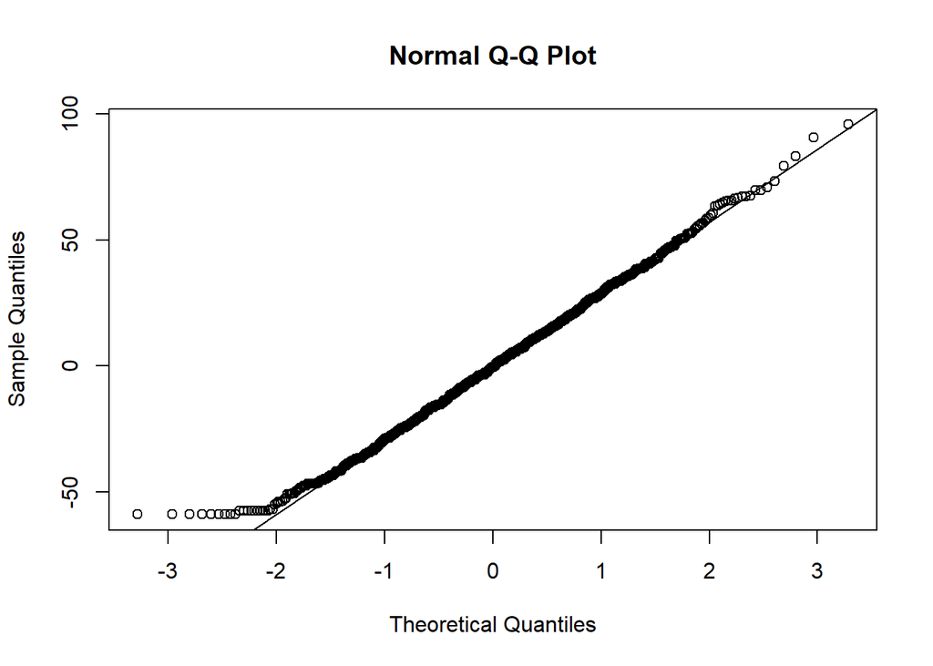

```r
qqnorm(residuals(test_anova))
qqline(residuals(test_anova))
```

Existe cierto incumplimiento del modelo en el extremo inferior de la distribución. No obstante el ANOVA es bastante resistente a la falta de normalidad, por lo que vamos a analizar sus resultados

### 1.2 ANOVA de una vía

Vamos a realizar el modelo ANOVA y a interpretar la salida en R

```r
# Realizar ANOVA
anova_results <- anova(test_anova)

# Mostrar los resultados
print(anova_results)
```

```
## Analysis of Variance Table
##
## Response: colesterol
##            Df Sum Sq Mean Sq F value    Pr(>F)
## clas_soc    2  18277  9138.6  11.397 1.279e-05 ***
## Residuals 981 786612   801.8
## ---
## Signif. codes:  0 '***' 0.001 '**' 0.01 '*' 0.05 '.' 0.1 ' ' 1
```

```r
# Extraer información específica
grados_libertad <- anova_results$Df
suma_cuadrados <- anova_results$`Sum Sq`
media_cuadrados <- anova_results$`Mean Sq`
estadistico_F <- anova_results$`F value`
p_valor <- anova_results$`Pr(>F)`

# Imprimir resultados específicos usando paste()
print(paste("Grados de libertad:", grados_libertad))
```

```
## [1] "Grados de libertad: 2"   "Grados de libertad: 981"
```

```r
print(paste("Suma de cuadrados:", suma_cuadrados))
```

```
## [1] "Suma de cuadrados: 18277.2647157692" "Suma de cuadrados: 786611.6621135"
```

```r
print(paste("Media de cuadrados:", media_cuadrados))
```

```
## [1] "Media de cuadrados: 9138.63235788459"
## [2] "Media de cuadrados: 801.84675037054"
```

```r
print(paste("Estadístico F:", estadistico_F))
```

```
## [1] "Estadístico F: 11.3969812232344" "Estadístico F: NA"
```

```r
print(paste("P-valor:", p_valor))
```

```
## [1] "P-valor: 1.27932836201877e-05" "P-valor: NA"
```

## 2. Comparaciones post-hoc tras un ANOVA

### 2.1 Varianzas homogéneas

Vamos a valorar si hay diferencias entre grupos con las correcciones de Bonferroni y Tukey, Primero usaremos la función `pairwise.t.test`

```r
resultado <- pairwise.t.test(df_iam4$colesterol,
    df_iam4$clas_soc, p.adjust.method = "bonferroni")
resultado
```

```
##
##  Pairwise comparisons using t tests with pooled SD
##
## data:  df_iam4$colesterol and df_iam4$clas_soc
##
##       Alta    Baja
## Baja  1.2e-05 -
## Media 0.00012 1.00000
##
## P value adjustment method: bonferroni
```

El resultado nos ofrece el p-value, pero no las diferencias. Esto si nos lo ofrece la función `TukeyHSD` siempre que previamente usemos la función `aov`

```r
anova_result <- aov(colesterol ~ clas_soc, data = df_iam4)
tukey_result <- TukeyHSD(anova_result)

tukey_result
```

```
##   Tukey multiple comparisons of means
##     95% family-wise confidence level
##
## Fit: aov(formula = colesterol ~ clas_soc, data = df_iam4)
##
## $clas_soc
##                 diff       lwr       upr     p adj
## Baja-Alta  12.257843  6.057827 18.457859 0.0000118
## Media-Alta 10.854327  4.671127 17.037527 0.0001213
## Media-Baja -1.403516 -6.034738  3.227706 0.7568360
```

También se pueden realizar comparaciones post-hoc utilizando la función `pairwiseTest` del paquete pairwiseCI en R. Con la sintaxis que utilizamos no ofrece IC.

```r
#install.packages("pairwiseCI")
# Solo hay que hacerlo una vez
library(pairwiseCI)
# Solo p-value sin ajuste
pw<-pairwiseTest(colesterol ~ clas_soc, data = df_iam4)
pw
```

```
## P-values calculated using
##  Welch Two Sample t-test
##
##
##            p.value
## Baja-Alta   0.0000
## Media-Alta  0.0000
## Media-Baja  0.4808
##
```

```r
ci_control <- pairwiseCI(colesterol ~ clas_soc, data = df_iam4,
              control = "Baja", conf.level = 1 - (0.05 /
              (length(unique(df_iam4$clas_soc)) - 1)))
ci_control
```

```
##
## 97.5 %-confidence intervals
##  Method:  Difference of means assuming Normal distribution, allowing unequal variances
##
##
##              estimate   lower  upper
## Alta - Baja   -12.258 -18.008 -6.508
## Media - Baja   -1.403  -5.872  3.065
##
##
```

Para hacer comparaciones post-hoc con sus intervalos de confianza el paquete más adecuado es `emmeans` . Primero usaremos la corrección de Bonferroni,

```r
#install.packages("emmeans")#solo si no está instalado previamente
library(emmeans)
```

```r
#Recuerda que tenemos test_anova

emm <- emmeans(test_anova, ~ clas_soc)
results_bonferroni<-pairs(emm, adjust = "bonferroni", infer = TRUE)
# infer = TRUE para IC
results_bonferroni
```

```
##  contrast     estimate   SE  df lower.CL upper.CL t.ratio p.value
##  Alta - Baja     -12.3 2.64 981   -18.59    -5.92  -4.641  <.0001
##  Alta - Media    -10.9 2.63 981   -17.17    -4.54  -4.121  0.0001
##  Baja - Media      1.4 1.97 981    -3.33     6.14   0.711  1.0000
##
## Confidence level used: 0.95
## Conf-level adjustment: bonferroni method for 3 estimates
## P value adjustment: bonferroni method for 3 tests
```

Ahora con las correcciones de Tukey, Holm-Bonferroni y Dunnett,

```r
results_tukey <- pairs(emm, adjust = "tukey", infer = TRUE)
results_tukey
```

```
##  contrast     estimate   SE  df lower.CL upper.CL t.ratio p.value
##  Alta - Baja     -12.3 2.64 981   -18.46    -6.06  -4.641  <.0001
##  Alta - Media    -10.9 2.63 981   -17.04    -4.67  -4.121  0.0001
##  Baja - Media      1.4 1.97 981    -3.23     6.03   0.711  0.7568
##
## Confidence level used: 0.95
## Conf-level adjustment: tukey method for comparing a family of 3 estimates
## P value adjustment: tukey method for comparing a family of 3 estimates
```

```r
results_holm <- pairs(emm, adjust = "holm", infer = TRUE)
results_holm
```

```
##  contrast     estimate   SE  df lower.CL upper.CL t.ratio p.value
##  Alta - Baja     -12.3 2.64 981   -18.59    -5.92  -4.641  <.0001
##  Alta - Media    -10.9 2.63 981   -17.17    -4.54  -4.121  0.0001
##  Baja - Media      1.4 1.97 981    -3.33     6.14   0.711  0.4770
##
## Confidence level used: 0.95
## Conf-level adjustment: bonferroni method for 3 estimates
## P value adjustment: holm method for 3 tests
```

```r
results_dunnett <- pairs(emm, adjust = "dunnett", infer = TRUE)
results_dunnett
```

```
##  contrast     estimate   SE  df lower.CL upper.CL t.ratio p.value
##  Alta - Baja     -12.3 2.64 981   -18.50    -6.02  -4.641  <.0001
##  Alta - Media    -10.9 2.63 981   -17.08    -4.63  -4.121  0.0001
##  Baja - Media      1.4 1.97 981    -3.26     6.07   0.711  0.7902
##
## Confidence level used: 0.95
## Conf-level adjustment: dunnettx method for 3 estimates
## P value adjustment: dunnettx method for 3 tests
```

### 2.2 Varianzas no homogéneas

La última función utilizada permite ser usada en casos de varianzas no homogéneas, pero la comparación formal post-hoc para varianzas no homogéneas es el test de Tamhane, que necesita del paquete `PMCMRplus`

```r
#install.packages("PMCMRplus")
library(PMCMRplus)
df_iam4$clas_soc<- as.factor(df_iam4$clas_soc)

anova <- aov(colesterol ~ clas_soc, data = df_iam4)

# Aplicar el test de Tamhane T2
summary(T2b <- tamhaneT2Test(anova, welch = FALSE))
```

```
##
##  Pairwise comparisons using Tamhane's T2'-test for unequal variances
```

```
## data: colesterol by clas_soc
```

```
## alternative hypothesis: two.sided
```

```
## P value adjustment method: T2' (Sidak)
```

```
## H0
```

```
##                   t value   Pr(>|t|)
## Baja - Alta == 0    4.802 6.0428e-06 ***
## Media - Alta == 0   4.241 7.7859e-05 ***
## Media - Baja == 0  -0.705    0.86007
```

```
## Signif. codes: 0 '***' 0.001 '**' 0.01 '*' 0.05 '.' 0.1 ' ' 1
```

Si se sospecha que las varianzas de los grupos son significativamente diferentes, se debería usar welch = TRUE para realizar una versión de ANOVA de Welch y asegurar resultados más robustos.

## 3. Test de Kruskal-Wallis

Vamos a valorar si hay diferencias en el `imc` por clase social. Primero dibujamos unos diagramas de cajas

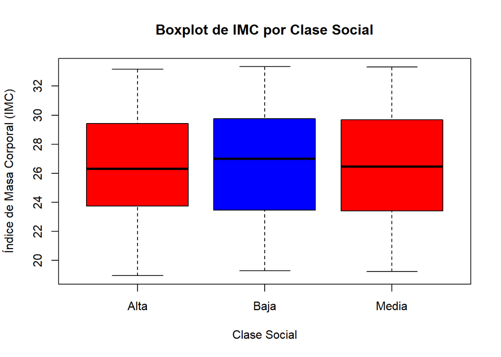

```r
boxplot(imc ~ clas_soc, data = df_iam4,
        main = "Boxplot de IMC por Clase Social",
        xlab = "Clase Social",
        ylab = "Índice de Masa Corporal (IMC)",
        col = c("red", "blue"),  # Colores para las cajas
        border = "black")  # Color del borde
```

Parece no haber grandes diferencias. Vamos a estudiarlo con un test. Primero estudiamos la normalidad e igualdad de varianzas

```r
by(df_iam4$imc, df_iam4$clas_soc, shapiro.test)
```

```
## df_iam4$clas_soc: Alta
##
##  Shapiro-Wilk normality test
##
## data:  dd[x, ]
## W = 0.969, p-value = 0.001166
##
## ------------------------------------------------------------
## df_iam4$clas_soc: Baja
##
##  Shapiro-Wilk normality test
##
## data:  dd[x, ]
## W = 0.96158, p-value = 7.593e-09
##
## ------------------------------------------------------------
## df_iam4$clas_soc: Media
##
##  Shapiro-Wilk normality test
##
## data:  dd[x, ]
## W = 0.96631, p-value = 3.457e-08
```

```r
leveneTest(imc ~ clas_soc, data = df_iam4)
```

```
## Levene's Test for Homogeneity of Variance (center = median)
##        Df F value Pr(>F)
## group   2  0.1594 0.8526
##       981
```

No se cumple el supuesto de normalidad pero si el de homogeneidad de varianzas. Utilizamos la prueba de Kruskal Wallis:

```r
kruskal_test_result <- kruskal.test(imc ~ clas_soc, data = df_iam4)

# Mostrar el resultado
print(kruskal_test_result)
```

```
##
##  Kruskal-Wallis rank sum test
##
## data:  imc by clas_soc
## Kruskal-Wallis chi-squared = 0.66495, df = 2, p-value = 0.7171
```

Efectivamente, no se observan diferencias entre grupos.